# SwiftKey Dataset - Exploratory Analysis and Prediction Algorithm Summary

Ted Yun

## Introduction

In this report we perform exploratory analysis on the SwiftKey datasets and summarize a plan for building a prediction algorithm based on the datasets.

## Data Statistics

The SwiftKey dataset consists of text in four different languages, namely German, English, Finnish, and Russian. In this analysis we will only consider text in English language. English language corpus in the dataset is from three different sources - blogs, news, and twitter.

The three datasets differ drastically in terms of the number of texts and the length of each text. In terms of the number of texts in a dataset, the twitter data have the most texts containing 2,340,148 texts, followed by the blogs data (899,288 texts), and the news data (77,259 texts).

The text in blog data and the text in news data have similar length, containing on average 231.7 letters and 203 letters respectively. The text in twitter data is much shorter, 68.8 letters on average, which is not surprising as twitter limits the number of characters in each tweet.

Blog data letter counts:

```
##    Min. 1st Qu.  Median    Mean 3rd Qu.    Max.
##     1.0    47.0   157.0   231.7   331.0 40840.0
```

News data letter counts:

```
##    Min. 1st Qu.  Median    Mean 3rd Qu.    Max.
##       2     111     186     203     270    5760
```

Twitter data letter counts:

```
##    Min. 1st Qu.  Median    Mean 3rd Qu.    Max.
##     2.0    37.0    64.0    68.8   100.0   213.0
```

Let us look at the number of words in each text.

Blog data word counts:

```
##    Min. 1st Qu.  Median    Mean 3rd Qu.    Max.
##    1.00    9.00   28.00   41.97   60.00 6819.00
```

News data word counts:

```
##    Min. 1st Qu.  Median    Mean 3rd Qu.    Max.
##    1.00   19.00   32.00   34.98   46.00 1440.00
```

Twitter data word counts:

```
##    Min. 1st Qu.  Median    Mean 3rd Qu.    Max.
##    1.00    7.00   12.00   12.96   18.00   47.00
```

Here are histograms of the word counts in three datasets. Not surprisingly, the news dataset exhibits the most well-formed bell curve among the three, while in the blog and twitter dataset a large portion of the texts are short. On average, the text in the blog data has 42 words, the text in the news data has 35 words, and the text in the twitter data has only 13 words.

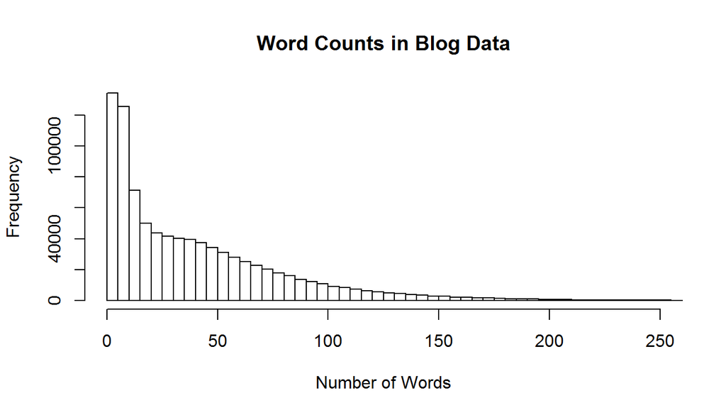

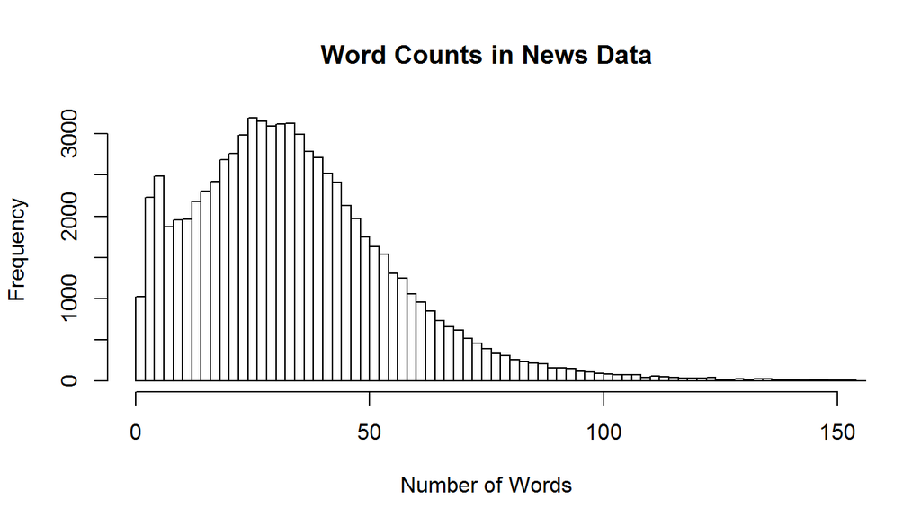

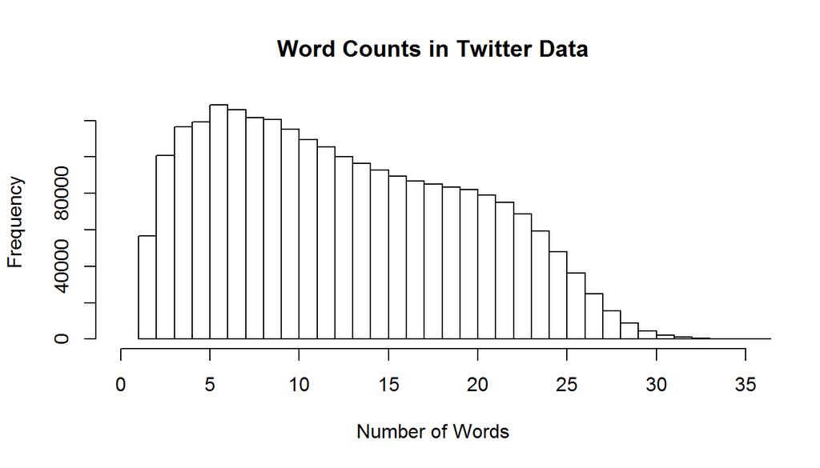

Finally, let us look more closely at the contents of the dataset. We take the news dataset and tokenize the sentences into words. In our analysis we found 94083 different words (case-insensitive) in the news data. Here is the list of top 50 words that was used in the news data, along with the frequencies they appeared.

```
##    the     to    and      a     of     in    for   that     is     on
## 151123  69687  68331  68199  59292  51799  27101  26305  21938  20766
##   with   said    was     he     it     at     as    his     be   from
##  19698  19168  17613  17452  16552  16451  14565  12091  11623  11612
##    but      i   have    are     by     an    has   this    not   they
##  11562  11498  10991  10714  10297   9392   9328   9319   8582   8570
##   will    who     or    you     we  about    one   more  their    had
##   8464   8310   7407   7318   7199   6907   6796   6726   6700   6267
##     up   year   when    out    she   were    all  would    her    new
##   5976   5939   5880   5770   5755   5634   5560   5554   5354   5342
```

## Prediction Algorithm

Our final goal is to create a lightweight application – suitable for mobile environment – that predicts the next word a user wants to type in. We will use n-gram model for the prediction. Using this n-gram model, we will predict the next word based on the previous n words that appeared in the text.

Given the restriction of processing speed and memory in our current mobile devices, we plan to use the two-gram model, in other words, the previous two words will be used to predict the user’s next word. When the combination of the previous two words were never seen in our data, we will fall back to the one-gram model, using only the last word to predict the next word.

The directed-graph data structure will be used to store the two-gram model. Each vertex of the graph will store a two-gram, and each outgoing edge will store the probability of the next two-gram appearing in a text. A directed graph can be implemented as a matrix.